# Reproducible Research: Peer Assessment 1

## Loading and preprocessing the data

```r
dset <- read.csv("D:/RWSPACE/Project5_A1/activity.csv",header = TRUE)
dset <- transform(dset, date = as.Date(date))
```

## What is mean total number of steps taken per day?

Make a histogram of the total number of steps taken each day Used the aggregate function to calculate the total number of steps taken each day hist function for plotting the histogram

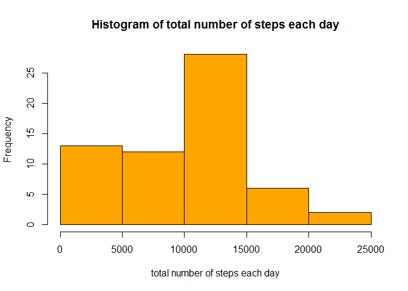

```r
stepsum <- data.frame(aggregate(dset$steps,by=list(dset$date),sum,na.rm=TRUE))
names(stepsum) <- c("day","total.steps")
hist(stepsum$total.steps,xlab = "total number of steps each day",main = "Histogram of total number of steps each day", col="orange")
```

```r
step.mean <- data.frame(aggregate(dset$steps,by=list(dset$date),mean,na.rm=TRUE))
names(step.mean) <- c("day","mean.steps")
step.median <- data.frame(aggregate(dset$steps,by=list(dset$date),median,na.rm=TRUE))
names(step.median) <- c("day","median.steps")
paste("Mean of total number of steps taken per day")
```

```
## [1] "Mean of total number of steps taken per day"
```

```r
step.mean
```

```
##           day mean.steps
## 1  2012-10-01        NaN
## 2  2012-10-02  0.4375000
## 3  2012-10-03 39.4166667
## 4  2012-10-04 42.0694444
## 5  2012-10-05 46.1597222
## 6  2012-10-06 53.5416667
## 7  2012-10-07 38.2465278
## 8  2012-10-08        NaN
## 9  2012-10-09 44.4826389
## 10 2012-10-10 34.3750000
## 11 2012-10-11 35.7777778
## 12 2012-10-12 60.3541667
## 13 2012-10-13 43.1458333
## 14 2012-10-14 52.4236111
```

[output cut: 47 more lines]

```r
paste("Median of total number of steps taken per day")
```

```
## [1] "Median of total number of steps taken per day"
```

```r
step.median
```

```
##           day median.steps
## 1  2012-10-01           NA
## 2  2012-10-02            0
## 3  2012-10-03            0
## 4  2012-10-04            0
## 5  2012-10-05            0
## 6  2012-10-06            0
## 7  2012-10-07            0
## 8  2012-10-08           NA
## 9  2012-10-09            0
## 10 2012-10-10            0
## 11 2012-10-11            0
## 12 2012-10-12            0
## 13 2012-10-13            0
## 14 2012-10-14            0
```

[output cut: 47 more lines]

## What is the average daily activity pattern?

1.A time series plot of the 5-minute interval (x-axis) and the average number of steps taken, averaged across all days (y-axis)

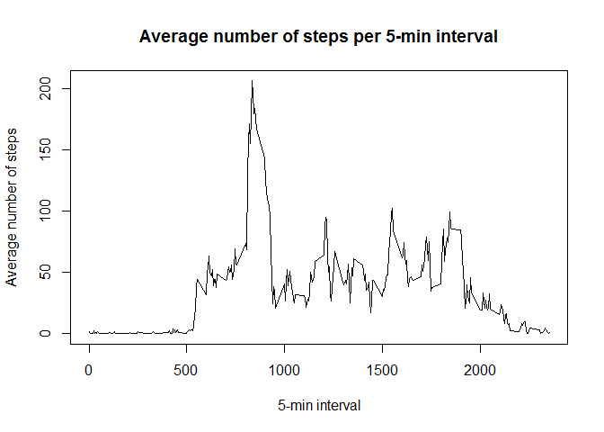

```r
interval <- aggregate(dset$steps,by=list(dset$interval),mean,na.rm=TRUE)
names(interval) <- c("interv","average")
with(interval,plot(interv,average,type="l",xlab ="5-min interval",ylab = "Average number of steps",main = "Average number of steps per 5-min interval"))
```

The 5-minute interval, on average across all the days containing the maximum number of steps

```r
interval$interv[which.max(interval$average)]
```

```
## [1] 835
```

## Imputing missing values

1.Calculate and report the total number of missing values in the dataset

```r
total.NA <- length(dset$steps[is.na(dset$steps)==TRUE])
percent.NA <- total.NA/length(dset$steps)
sprintf("NA values represent %1.2f%% of the observations total number",100*percent.NA)
```

```
## [1] "NA values represent 13.11% of the observations total number"
```

2.Imputing the missing values by replace NAs by the mean of that 5-min interval

```r
imputed <- dset
##Code for imputing missing values
for(i in 1:17568){
      if (is.na(imputed$steps[i])==TRUE){
            indic <- imputed$interval[i]
            imputed$steps[i] <- interval$average[match(indic,interval$interv)]
      }
}
```

[figure not shown]

```r
stepsum1 <- data.frame(aggregate(imputed$steps,by=list(imputed$date),sum,na.rm=TRUE))
names(stepsum1) <- c("day","total.steps")
hist(stepsum$total.steps,xlab = "total number of steps each day",main = "Histogram of total number of steps each day after imputing NAs", col="green")
```

```r
step.mean_ <- data.frame(aggregate(imputed$steps,by=list(imputed$date),mean,na.rm=TRUE))
names(step.mean_) <- c("day","mean.steps")
step.median_ <- data.frame(aggregate(imputed$steps,by=list(imputed$date),median,na.rm=TRUE))
names(step.median_) <- c("day","median.steps")
paste("Mean of total number of steps taken per day")
```

```
## [1] "Mean of total number of steps taken per day"
```

```r
step.mean_
```

```
##           day mean.steps
## 1  2012-10-01 37.3825996
## 2  2012-10-02  0.4375000
## 3  2012-10-03 39.4166667
## 4  2012-10-04 42.0694444
## 5  2012-10-05 46.1597222
## 6  2012-10-06 53.5416667
## 7  2012-10-07 38.2465278
## 8  2012-10-08 37.3825996
## 9  2012-10-09 44.4826389
## 10 2012-10-10 34.3750000
## 11 2012-10-11 35.7777778
## 12 2012-10-12 60.3541667
## 13 2012-10-13 43.1458333
## 14 2012-10-14 52.4236111
```

[output cut: 47 more lines]

```r
paste("Median of total number of steps taken per day")
```

```
## [1] "Median of total number of steps taken per day"
```

```r
step.median_
```

```
##           day median.steps
## 1  2012-10-01     34.11321
## 2  2012-10-02      0.00000
## 3  2012-10-03      0.00000
## 4  2012-10-04      0.00000
## 5  2012-10-05      0.00000
## 6  2012-10-06      0.00000
## 7  2012-10-07      0.00000
## 8  2012-10-08     34.11321
## 9  2012-10-09      0.00000
## 10 2012-10-10      0.00000
## 11 2012-10-11      0.00000
## 12 2012-10-12      0.00000
## 13 2012-10-13      0.00000
## 14 2012-10-14      0.00000
```

[output cut: 47 more lines]

We can notice Only NA values have changed into valid values, for the others, no changes were recorded

## Are there differences in activity patterns between weekdays and weekends?

First, we create a new factor variable in the dataset with two levels - “weekday” and “weekend” indicating whether a given date is a weekday or weekend day

```r
library(dplyr)
weekday <- mutate(imputed,category=weekdays(imputed$date))
for(i in 1:17568){
      if (weekday$category[i]=="samedi"|| weekday$category[i]=="dimanche"){
            weekday$category[i] <- paste("weekend")
      }
      else weekday$category[i] <- paste("weekday")
}
weekday <- transform(weekday,category=as.factor(category))
benchmark <- aggregate(weekday$steps,by=list(weekday$interval,weekday$category),mean)
names(benchmark) <- c("inter","category","avg")
```

Panel plot containing a time series plot of the 5-minute interval (x-axis) and the average number of steps taken, averaged across all weekday days or weekend days (y-axis)

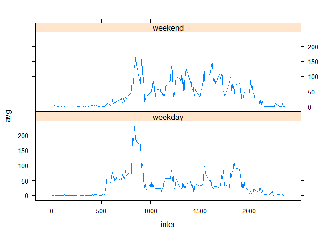

```r
library(lattice)
xyplot(avg ~ inter | category, data = benchmark,layout=c(1,2), type="l",lty=1)
```

We notice that the maximum average number of steps isreached in weekdays, but in general, and accross the day, the activity is more important in weekends than in weekdays